# PSY 8960 Week 8 Project

Chulin Chen

2023-03-14

# Reproducible Image and Online Resources

An image of this project as of *2024-01-29* can be accessed by [clicking this link](https://mybinder.org/v2/gh/ChulinChen20/psy8960-week8.git/HEAD).

An interactive web app is available by [clicking this link instead](https://chulinchen23.shinyapps.io/shiny_week8/).

# Script Settings and Resources

Set the working directory to where the RMarkdown File is in, load all the necessary packages, and suppress outputs. message=FALSE is used as the only output is the meassage from tidyverse.

```r
setwd(dirname(rstudioapi::getActiveDocumentContext()$path))
library(ggplot2)
library(tidyverse)
```

# Data Import and Cleaning

Import dataset, convert the reversed coded variable q5, and convert variables to types appropriate for later analysis.

```r
week8_tbl <-read_csv("../data/week3.csv",col_types=cols(timeStart=col_datetime(format="%Y-%m-%d %H:%M:%S"))) %>%
  mutate(q5=6-q5) %>%
  mutate(condition= factor(condition, levels = c("A","B","C"),labels=c("Block A","Block B","Control"))) %>%
  mutate(gender= factor(gender, levels = c("M","F"),labels=c("Male","Female")))%>%
  mutate(timeStart = ymd_hms(timeStart)) %>%
  mutate(mean1 = rowMeans(across(q1:q6)),
         mean2 = rowMeans(across(q8:q10))) %>%
  mutate(after_aug2017 = timeEnd > "2017-08-01 00:00:00")
```

# Visualization

Display a table of data in q1-q6 using the package DT as it creates paginated tables. Create a scatterplot between mean scores on Q1-Q6 (x-axis) and mean scores on Q8-Q10 (y-axis), relabel axes for clearer presentation.

```
## # A tibble: 49 × 6
##       q1    q2    q3    q4    q5    q6
##    <dbl> <dbl> <dbl> <dbl> <dbl> <dbl>
##  1     5     4     4     1     2     1
##  2     2     4     3     1     3     1
##  3     5     5     2     1     5     1
##  4     4     3     4     2     4     1
##  5     3     1     3     5     2     1
##  6     4     3     2     3     3     1
##  7     2     4     1     3     1     1
##  8     4     2     5     1     1     1
##  9     2     5     3     4     2     1
## 10     3     4     2     4     5     1
## # ℹ 39 more rows
```

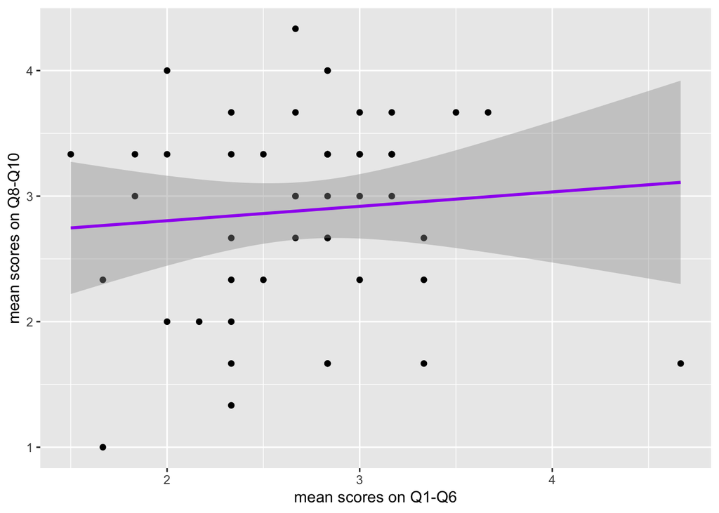

# Analysis

Display output summarizing the correlation between the two mean scores.

```r
cor.test(week8_tbl$mean1, week8_tbl$mean2)
```

```
##
##  Pearson's product-moment correlation
##
## data:  week8_tbl$mean1 and week8_tbl$mean2
## t = 0.58309, df = 47, p-value = 0.5626
## alternative hypothesis: true correlation is not equal to 0
## 95 percent confidence interval:
##  -0.2012466  0.3574248
## sample estimates:
##        cor
## 0.08474575
```

The correlation coefficient is 0.0847457. Assuming that the alpha level is 0.05, as the p-value is greater than 0.05, the correlation is not significant.

# Data Export

Export data to a skinny RDS format data as it is most suitable for shiny app. Save the data to a folder containing the app.

```r
week8_tbl %>%
  select(mean1, mean2,
         gender, after_aug2017) %>%
  saveRDS("../shiny_week8/shiny_skinny.RDS")
```